# Habitat Type Choice Analysis

Load the Sun Shade header file:

```r
source("./_sun_shade_header.R")
```

Load data:

```r
# data for 2014 field:
d14f <- read.table("./data/habitat_choice/field.master.data_2014.csv", T, ",")

# modify factor names and coding
names(d14f)[2] <- c("temp")
d14f[,'cage'] <- d14f[,'temp']
levels(d14f[,'cage'])[1] <- 1
levels(d14f[,'cage'])[2] <- 2
d14f$trial <- factor(d14f$trial)

# data for 2014 and 2015 lab:
both <- read.table("./data/habitat_choice/lab_temps_bothyears.txt", T, "\t")
both$year  <- factor(both$year)
both$batch <- factor(both$batch)
both$batch_2015 <- factor(both$batch_2015)
both$cage  <- factor(both$cage)
both$side  <- factor(both$side)
both$room  <- factor(both$room)

# per YEAR: first do each analysis separately:
d14l <- dplyr::filter(both, year == 2014)
d15l <- dplyr::filter(both, year == 2015)
```

## 2014 Field trials (stipples) (2014 Response A)

### Plots

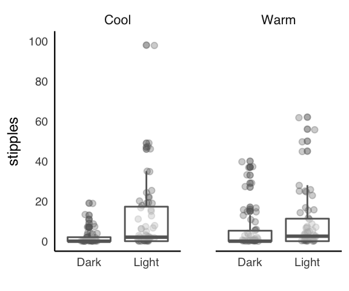

```r
d14f.1 <- ggplot(d14f, aes(x = light, y = stipples)) + facet_wrap(~ temp) +
  geom_jitter(width = 0.15, alpha = 0.3, col = "gray40") +
  geom_boxplot(alpha = 0.5, col = "gray40") + theme_pth1() +
  scale_y_continuous(limits = c(0,100), breaks = seq(0,100,20)) + xlab("") + ylab("stipples")

print(d14f.1)
```

### Models

First, run models (using *glmmTMB*) without consideration of adding condition-dependent dispersion parameters ($\phi_k$).

```r
## glmmTMB
d14f.nb0  <- glmmTMB(stipples ~ 1 + (1|trial/cage/side), data = d14f, family = nbinom2)
d14f.nb1  <- glmmTMB(stipples ~ width + (1|trial/cage/side), data = d14f,family = nbinom2)
d14f.nb2  <- glmmTMB(stipples ~ width + light + (1|trial/cage/side), data = d14f,family = nbinom2)
d14f.nb3  <- glmmTMB(stipples ~ width + light + temp + (1|trial/cage/side), data = d14f,family = nbinom2)
d14f.nb3b <- glmmTMB(stipples ~ width + light * temp + (1|trial/cage/side), data = d14f, family = nbinom2)
```

Compare these models via $\Delta \text{AIC}_c$:

```r
ICtab(d14f.nb0,d14f.nb1,d14f.nb2,d14f.nb3,d14f.nb3b, type = 'AICc')
```

```
##           dAICc df
## d14f.nb2   0.0  7
## d14f.nb3b  0.6  9
## d14f.nb3   0.9  8
## d14f.nb1   6.3  6
## d14f.nb0  37.6  5
```

It looks like the model that only included only light, and not temperature or its interaction with light, is the favored model.

Let’s see if this changes after re-estimating each of these models after including condition-specific dispersion parameters:

```r
d14f.nb0.d1  <- glmmTMB(stipples ~ 1 + (1|trial/cage/side), dispformula = ~ light, data = d14f, family = nbinom2)
d14f.nb1.d1  <- glmmTMB(stipples ~ width + (1|trial/cage/side), dispformula = ~ light, data = d14f,family = nbinom2)
d14f.nb2.d1  <- glmmTMB(stipples ~ width + light + (1|trial/cage/side), dispformula = ~ light, data = d14f,family = nbinom2)
d14f.nb3.d1  <- glmmTMB(stipples ~ width + light + temp + (1|trial/cage/side), dispformula = ~ light, data = d14f,family = nbinom2)
d14f.nb3b.d1 <- glmmTMB(stipples ~ width + light * temp + (1|trial/cage/side), dispformula = ~ light, data = d14f, family = nbinom2)
d14f.nb3b.d1.z <- glmmTMB(stipples ~ width + light * temp + (1|trial/cage/side), dispformula = ~ light, zi = ~1, data = d14f, family = nbinom2)
d14f.nb3b.d1.z2 <- glmmTMB(stipples ~ width + light * temp + (1|trial/cage/side), dispformula = ~ light, zi = ~ 0 + light, data = d14f, family = nbinom2)


# adding temp to dispersion term:
d14f.nb3.d1.z1  <- glmmTMB(stipples ~ width + light + temp + (1|trial/cage/side), dispformula = ~light + temp, data = d14f,family = nbinom2)
d14f.nb2.d1.z1  <- glmmTMB(stipples ~ width + light + (1|trial/cage/side), dispformula = ~ light + temp, data = d14f,family = nbinom2)
```

Compare these models via $\Delta \text{AIC}_c$:

```r
ICtab(d14f.nb2.d1.z1,d14f.nb3.d1.z1,d14f.nb3b.d1.z,d14f.nb3b.d1.z2,
      d14f.nb0.d1,d14f.nb1.d1,d14f.nb2.d1,d14f.nb3.d1,d14f.nb3b.d1, type = 'AICc')
```

```
##                 dAICc df
## d14f.nb2.d1      0.0  8
## d14f.nb3b.d1     1.2  10
## d14f.nb3.d1      1.2  9
## d14f.nb2.d1.z1   1.8  9
## d14f.nb3b.d1.z   2.6  11
## d14f.nb3.d1.z1   3.2  10
## d14f.nb3b.d1.z2  4.5  12
## d14f.nb1.d1      5.6  7
## d14f.nb0.d1     33.6  6
```

Again, the same base model is preferred. Let’s quantify the improvement of adding the extra dispersion term:

```r
ICtab(d14f.nb0,d14f.nb1,d14f.nb2,d14f.nb3,d14f.nb3b,d14f.nb0.d1,
      d14f.nb1.d1,d14f.nb2.d1,d14f.nb3.d1,d14f.nb3b.d1, type = 'AICc')
```

```
##              dAICc df
## d14f.nb2.d1   0.0  8
## d14f.nb3b.d1  1.2  10
## d14f.nb3.d1   1.2  9
## d14f.nb2      2.4  7
## d14f.nb3b     3.1  9
## d14f.nb3      3.3  8
## d14f.nb1.d1   5.6  7
## d14f.nb1      8.8  6
## d14f.nb0.d1  33.6  6
## d14f.nb0     40.0  5
```

We will report model `d14f.nb2.d1`.

Output model coefficients:

```r
#d14f.bm <- d14f.nb3b.d1
d14f.bm <- d14f.nb2.d1
d14f.ci <- confint(d14f.bm)
d14f.coef <- do.call(rbind,summary(d14f.bm)$coef)
round(d14f.ci,2)
```

```
##                                            2.5 % 97.5 % Estimate
## cond.(Intercept)                           -2.36  -0.22    -1.29
## cond.width                                  0.04   0.09     0.07
## cond.lightLight                             0.46   2.17     1.31
## cond.Std.Dev.side:(cage:trial).(Intercept)  0.43   1.52     0.81
## cond.Std.Dev.cage:trial.(Intercept)         0.00    Inf     0.00
## cond.Std.Dev.trial.(Intercept)              0.08   2.04     0.40
## sigma                                       0.15   0.38     0.24
## sigma                                       1.05   3.24     1.85
```

Output coefficient estimates with p-values:

```r
round(d14f.coef,4)
```

```
##             Estimate Std. Error z value Pr(>|z|)
## (Intercept)  -1.2886     0.5465 -2.3579   0.0184
## width         0.0685     0.0124  5.5159   0.0000
## lightLight    1.3142     0.4382  2.9994   0.0027
## (Intercept)  -1.4213     0.2355 -6.0348   0.0000
## lightLight    0.6128     0.2868  2.1366   0.0326
```

Simulate model to report:

```r
# simulate model:
set.seed(12345)
d14f.sim <- simulate(d14f.bm, nsim = 1000)
```

Plot predictive distributions:

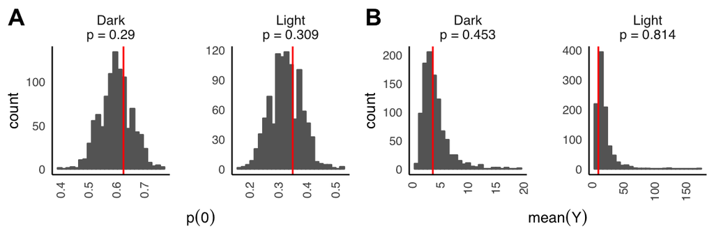

```r
d14f.pp <- pp.plots(thesim = d14f.sim, thedat = d14f, thefact = 'light', theresponse = 'stipples')
print(d14f.pp$plots)
```

Report summary of test statistics:

```r
print(d14f.pp$means)
```

```
## # A tibble: 2 x 4
##     fact       mu2    lower     upper
##   <fctr>     <dbl>    <dbl>     <dbl>
## 1   Dark  4.009942 1.441667  9.992292
## 2  Light 18.246183 6.414167 52.768958
```

```r
print(d14f.pp$p0)
```

```
## # A tibble: 2 x 4
##                fact1        p0     lower     upper
##               <fctr>     <dbl>     <dbl>     <dbl>
## 1   "Dark\np = 0.29" 0.5985333 0.4916667 0.7083333
## 2 "Light\np = 0.309" 0.3260167 0.2166667 0.4250000
```

```r
print(d14f.pp$intensity)
```

```
## # A tibble: 2 x 4
##     fact       mu2    lower    upper
##   <fctr>     <dbl>    <dbl>    <dbl>
## 1   Dark  9.831306 4.171120 23.16299
## 2  Light 26.902710 9.998563 73.88196
```

## 2014 Laboratory trials (stipples) (2014 Response B)

### Plots

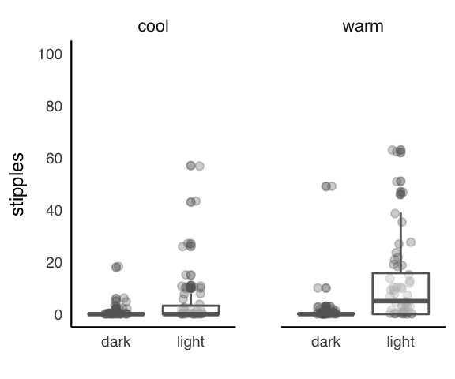

```r
d14l.1 <- ggplot(d14l, aes(x = light, y = stipples)) + facet_wrap(~ temp) +
  geom_jitter(width = 0.15, alpha = 0.3, col = "gray40") +
  geom_boxplot(alpha = 0.5, col = "gray40") + theme_pth1() +
  scale_y_continuous(limits = c(0,100), breaks = seq(0,100,20)) + xlab("") + ylab("stipples")

print(d14l.1)
```

### Models

Run models:

```r
d14l.0  <- glmmTMB(stipples ~ 1 + (1|batch/room/side), data = d14l, family = nbinom2)
d14l.1  <- glmmTMB(stipples ~ width + (1|batch/room/side), data = d14l, family = nbinom2)
d14l.2  <- glmmTMB(stipples ~ width + temp + (1|batch/room/side), data = d14l, family = nbinom2)
d14l.3  <- glmmTMB(stipples ~ width + light + (1|batch/room/side), data = d14l, family = nbinom2)
d14l.4  <- glmmTMB(stipples ~ width + light + temp + (1|batch/room/side), data = d14l, family = nbinom2)
d14l.5  <- glmmTMB(stipples ~ width + light * temp + (1|batch/room/side), data = d14l, family = nbinom2)

ICtab(d14l.0,d14l.1,d14l.2,d14l.3,d14l.4,d14l.5,type = 'AICc')
```

```
##        dAICc df
## d14l.4  0.0  8
## d14l.3  0.4  7
## d14l.5  1.3  9
## d14l.1  9.6  6
## d14l.2 10.1  7
## d14l.0 14.9  5
```

Elaborating these models with condition-specific $\phi_k$ and including zero-inflation $\pi_0$:

```r
d14l.4.d1  <- glmmTMB(stipples ~ width + light + temp + (1|batch/room/side), dispformula = ~ light, data = d14l, family = nbinom2)
d14l.4.d2  <- glmmTMB(stipples ~ width + light + temp + (1|batch/room/side), dispformula = ~ temp, data = d14l, family = nbinom2)
d14l.4.d1b  <- glmmTMB(stipples ~ width + light + temp + (1|batch/room/side), dispformula = ~ light + temp, data = d14l, family = nbinom2)
d14l.4.d1c  <- glmmTMB(stipples ~ width + light + temp + (1|batch/room/side), dispformula = ~ light * temp, data = d14l, family = nbinom2)

d14l.4.d1e  <- glmmTMB(stipples ~ width + light * temp + (1|batch/room/side), dispformula = ~ light + temp, data = d14l, family = nbinom2)

# simplify by removing main effect of temperature
d14l.4.d1b0  <- glmmTMB(stipples ~ width + light + (1|batch/room/side), dispformula = ~ light + temp, data = d14l, family = nbinom2)

# d14l.4.d2  <- glmmTMB(stipples ~ width + light + temp + (1|batch/room/side), zi = ~1, data = d14l, family = nbinom2)
# d14l.4.d3  <- glmmTMB(stipples ~ width + light + temp + (1|batch/room/side), zi = ~light, data = d14l, family = nbinom2)
# d14l.4.d4  <- glmmTMB(stipples ~ width + light + temp + (1|batch/room/side), zi = ~1, dispformula = ~0 + light, data = d14l, family = nbinom2) # didn't converge
```

```r
ICtab(d14l.4.d1e,d14l.4.d2,d14l.4.d1b0,d14l.4.d1,d14l.4.d1b,
      d14l.4.d1c,d14l.0,d14l.1,d14l.2,d14l.3,d14l.4,d14l.5,type = 'AICc')
```

```
##             dAICc df
## d14l.4.d1b   0.0  10
## d14l.4.d1b0  0.4  9
## d14l.4.d1e   1.3  11
## d14l.4.d1c   1.9  11
## d14l.4.d1    5.7  9
## d14l.4.d2    8.8  9
## d14l.4      14.9  8
## d14l.3      15.3  7
## d14l.5      16.2  9
## d14l.1      24.5  6
## d14l.2      25.0  7
## d14l.0      29.9  5
```

Output coefficients of model to report:

```r
d14l.bm <- d14l.4.d1b
d14l.ci <- confint(d14l.bm)
d14l.coef <- do.call(rbind,summary(d14l.bm)$coef)
round(d14l.ci,3)
```

```
##                                             2.5 % 97.5 % Estimate
## cond.(Intercept)                           -3.972 -0.801   -2.387
## cond.width                                  0.019  0.117    0.068
## cond.lightlight                             1.017  3.224    2.120
## cond.tempwarm                              -0.153  1.958    0.903
## cond.Std.Dev.side:(room:batch).(Intercept)  0.387  1.933    0.864
## cond.Std.Dev.room:batch.(Intercept)         0.000    Inf    0.000
## cond.Std.Dev.batch.(Intercept)              0.000    Inf    0.000
## sigma                                       0.025  0.123    0.055
## sigma                                       1.641  7.109    3.416
## sigma                                       1.326  4.914    2.553
```

Output coefficient estimates with p-values:

```r
print(round(d14l.coef,3))
```

```
##             Estimate Std. Error z value Pr(>|z|)
## (Intercept)   -2.387      0.809  -2.950    0.003
## width          0.068      0.025   2.747    0.006
## lightlight     2.120      0.563   3.767    0.000
## tempwarm       0.903      0.539   1.677    0.094
## (Intercept)   -2.893      0.405  -7.142    0.000
## lightlight     1.229      0.374   3.285    0.001
## tempwarm       0.937      0.334   2.806    0.005
```

Simulate model to report:

```r
# simulate model:
set.seed(12345)
d14l.sim <- simulate(d14l.bm, nsim = 1000)
```

Plot predictive distributions:

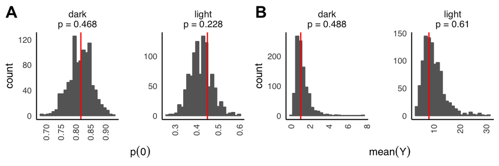

```r
# add additional factor to split predictions by temperature as well a light:
#d14l[,'condition'] <- paste0(d14l[,'light'],'_',d14l[,'temp'])
#d14l.pp2 <- pp.plots(thesim = d14l.sim, thedat = d14l, thefact = 'condition', theresponse = 'stipples', fourcats = TRUE)

d14l.pp <- pp.plots(thesim = d14l.sim, thedat = d14l, thefact = 'light', theresponse = 'stipples')
print(d14l.pp$plots)
```

Output summary of test statistics to report:

```r
print(d14l.pp$means)
```

```
## # A tibble: 2 x 4
##     fact      mu2     lower     upper
##   <fctr>    <dbl>     <dbl>     <dbl>
## 1   dark 1.145983 0.3414583  2.902083
## 2  light 9.729533 4.5143750 19.554167
```

```r
print(d14l.pp$p0)
```

```
## # A tibble: 2 x 4
##                fact1        p0     lower     upper
##               <fctr>     <dbl>     <dbl>     <dbl>
## 1  "dark\np = 0.468" 0.8150417 0.7416667 0.8833333
## 2 "light\np = 0.228" 0.4197333 0.3250000 0.5250000
```

```r
print(d14l.pp$intensity)
```

```
## # A tibble: 2 x 4
##     fact       mu2    lower    upper
##   <fctr>     <dbl>    <dbl>    <dbl>
## 1   dark  6.117319 2.498214 15.57760
## 2  light 16.643670 8.314145 32.50771
```

## 2015 Laboratory trials (stipples and eggs)

### Plots

First plot data broken down by temp and light treatment, with source habitat as an additional factor on the $x$-axis:

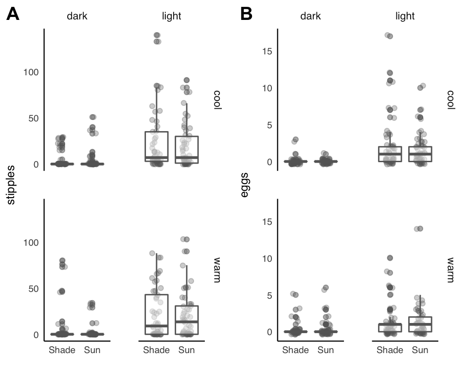

```r
# d15l.1 <- ggplot(d15l, aes(x = light, y = stipples)) + facet_wrap(~ temp) +
#   geom_jitter(width = 0.15, alpha = 0.3, col = "gray40") +
#   geom_boxplot(alpha = 0.5, col = "gray40") + theme_pth1() +
#   scale_y_continuous(limits = c(0,100), breaks = seq(0,100,20)) + xlab("") + ylab("stipples")
#
#
# d15l.2 <- ggplot(d15l, aes(x = light, y = eggs)) + facet_wrap(~ temp) +
#   geom_jitter(width = 0.15, alpha = 0.3, col = "gray40") +
#   geom_boxplot(alpha = 0.5, col = "gray40") + theme_pth1() +
#   scale_y_continuous(limits = c(0,20), breaks = seq(0,20,4)) + xlab("") + ylab("eggs")

d15l.1 <- ggplot(d15l, aes(x = source, y = stipples)) + facet_grid(temp ~ light) +
  geom_jitter(width = 0.15, alpha = 0.3, col = "gray40") +
  geom_boxplot(alpha = 0.5, col = "gray40") + theme_pth1() +
  #scale_y_continuous(limits = c(0,100), breaks = seq(0,100,20)) +
  xlab("") + ylab("stipples")


d15l.2 <- ggplot(d15l, aes(x = source, y = eggs)) + facet_grid(temp ~ light) +
  geom_jitter(width = 0.15, alpha = 0.3, col = "gray40") +
  geom_boxplot(alpha = 0.5, col = "gray40") + theme_pth1() +
  #scale_y_continuous(limits = c(0,20), breaks = seq(0,20,4)) +
  xlab("") + ylab("eggs")

ggarrange(plotlist = list(d15l.1,d15l.2), align = 'hv', ncol = 2, labels = c('A','B'))
```

### Models

#### Stipples

Run models:

```r
d15l.0  <- glmmTMB(stipples ~ 1 + (1|batch_2015/cage/side), data = d15l, family = nbinom2)
d15l.1  <- glmmTMB(stipples ~ width + (1|batch_2015/cage/side), data = d15l, family = nbinom2)
d15l.2  <- glmmTMB(stipples ~ width + light + (1|batch_2015/cage/side), data = d15l, family = nbinom2)
d15l.2b  <- glmmTMB(stipples ~ width + light + source + (1|batch_2015/cage/side), data = d15l, family = nbinom2)
d15l.3  <- glmmTMB(stipples ~ width + temp + (1|batch_2015/cage/side), data = d15l, family = nbinom2)
d15l.4  <- glmmTMB(stipples ~ width + light + temp + (1|batch_2015/cage/side), data = d15l, family = nbinom2)
d15l.5  <- glmmTMB(stipples ~ width + source + light + temp + (1|batch_2015/cage/side), data = d15l, family = nbinom2)
d15l.6 <- glmmTMB(stipples ~ width + source + light * temp + (1|batch_2015/cage/side), data = d15l, family = nbinom2)
d15l.7 <- glmmTMB(stipples ~ width + light * temp + (1|batch_2015/cage/side), data = d15l, family = nbinom2)
d15l.8 <- glmmTMB(stipples ~ width + source * light * temp + (1|batch_2015/cage/side), data = d15l, family = nbinom2)

ICtab(d15l.0,d15l.1,d15l.2,d15l.2b,d15l.3,d15l.4,d15l.5,d15l.6,d15l.7,d15l.8, type = 'AICc')
```

```
##         dAICc df
## d15l.2   0.0  7
## d15l.2b  0.6  8
## d15l.4   2.1  8
## d15l.5   2.7  9
## d15l.7   4.0  9
## d15l.6   4.6  10
## d15l.8   9.4  13
## d15l.0  19.2  5
## d15l.1  21.0  6
## d15l.3  23.1  7
```

Add to this best model condition-dependent estimation of $\phi_k$:

```r
d15l.2.d0 <- glmmTMB(stipples ~ width + light + (1|batch_2015/cage/side), dispformula = ~ 1, data = d15l, family = nbinom2)
d15l.2.d1 <- glmmTMB(stipples ~ width + light + (1|batch_2015/cage/side), dispformula = ~ light, data = d15l, family = nbinom2)
d15l.2.d2 <- glmmTMB(stipples ~ width + light + (1|batch_2015/cage/side), dispformula = ~ temp, data = d15l, family = nbinom2)
# d15l.2.d3 <- glmmTMB(stipples ~ width + light + (1|batch_2015/cage/side), dispformula = ~ light + temp, data = d15l, family = nbinom2)
# convergence-problems: don't consider this one.

# d15l.2.z1 <- glmmTMB(stipples ~ width + light + (1|batch_2015/cage/side), zi = ~ 1, data = d15l, family = nbinom2)
# d15l.2.z2 <- glmmTMB(stipples ~ width + light + (1|batch_2015/cage/side), zi = ~ light, data = d15l, family = nbinom2)
# non-positive definite Hessian; do not consider ZI henceforth.

ICtab(d15l.2.d0,d15l.2.d1, d15l.2.d2, type = 'AICc')
```

```
##           dAICc df
## d15l.2.d1  0.0  8
## d15l.2.d2 87.3  8
## d15l.2.d0 88.8  7
```

```r
# add back source to see how it impacts model:
d15l.2.d1.s0 <- glmmTMB(stipples ~ light + source + (1|batch_2015/cage/side), dispformula = ~ 0 + light, data = d15l, family = nbinom2)
d15l.2.d1.s0b <- glmmTMB(stipples ~ width + light + source + (1|batch_2015/cage/side), dispformula = ~ 0 + light, data = d15l, family = nbinom2) # convergence problems
d15l.2.d1.s2 <- glmmTMB(stipples ~ light * source + (1|batch_2015/cage/side), dispformula = ~ 0 + light, data = d15l, family = nbinom2)

ICtab(d15l.2.d1,d15l.2.d1.s0b,d15l.2.d1.s2,d15l.2.d1.s0,type = 'AICc')
```

```
##               dAICc df
## d15l.2.d1.s0  0.0   8
## d15l.2.d1     0.6   8
## d15l.2.d1.s0b 1.0   9
## d15l.2.d1.s2  2.1   9
```

Add back temp term with condition-dependent dispersion:

```r
# d15l.2.d1.2  <- glmmTMB(stipples ~ width + light + temp + (1|batch_2015/cage/side), dispformula = ~ light, data = d15l, family = nbinom2)
# d15l.2.d1.3  <- glmmTMB(stipples ~ width + light + temp + (1|batch_2015/cage/side), dispformula = ~ light + temp, data = d15l, family = nbinom2)
#
# ICtab(d15l.2.d1,d15l.2.d2,d15l.2.d1.2,d15l.2.d1.3,type = 'AICc')
```

Output coefficient estimates of reported model (`d15l.2.d1.s0b`)

```r
d15l.s.bm <- d15l.2.d1.s0b
d15l.s.ci <- confint(d15l.s.bm)
d15l.s.coef <- do.call(rbind,summary(d15l.s.bm)$coef)
round(d15l.s.coef,4)
```

```
##             Estimate Std. Error  z value Pr(>|z|)
## (Intercept)   0.4710     0.6794   0.6933   0.4881
## width         0.0210     0.0204   1.0328   0.3017
## lightlight    1.6709     0.3217   5.1938   0.0000
## sourceSun    -0.2669     0.2081  -1.2825   0.1997
## lightdark    -2.7185     0.1869 -14.5414   0.0000
## lightlight   -0.6594     0.1157  -5.6973   0.0000
```

Output CIs on estimates for best model:

```r
round(d15l.s.ci,2)
```

```
##                                                 2.5 % 97.5 % Estimate
## cond.(Intercept)                                -0.86   1.80     0.47
## cond.width                                      -0.02   0.06     0.02
## cond.lightlight                                  1.04   2.30     1.67
## cond.sourceSun                                  -0.67   0.14    -0.27
## cond.Std.Dev.side:(cage:batch_2015).(Intercept)  0.00    Inf     0.00
## cond.Std.Dev.cage:batch_2015.(Intercept)         0.94   2.12     1.41
## cond.Std.Dev.batch_2015.(Intercept)              0.00    Inf     0.00
## sigma                                            0.05   0.10     0.07
## sigma                                            0.41   0.65     0.52
```

Simulate best model:

```r
set.seed(12345)
d15l.s.sim <- simulate(d15l.s.bm, nsim = 1000)
```

Plot predictive distributions from simulation:

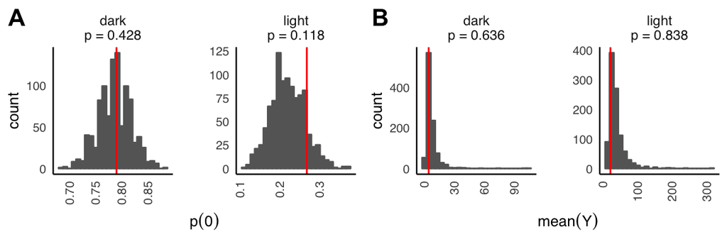

```r
d15l.s.pp <- pp.plots(thesim = d15l.s.sim, thedat = d15l, thefact = 'light', theresponse = 'stipples')
print(d15l.s.pp$plots)
```

Output summary of test statistics:

```r
print(d15l.s.pp$means)
```

```
## # A tibble: 2 x 4
##     fact       mu2    lower    upper
##   <fctr>     <dbl>    <dbl>    <dbl>
## 1   dark  7.167055  1.87425 21.39325
## 2  light 38.211076 14.67058 99.86427
```

```r
print(d15l.s.pp$p0)
```

```
## # A tibble: 2 x 4
##                fact1       p0     lower     upper
##               <fctr>    <dbl>     <dbl>     <dbl>
## 1  "dark\np = 0.428" 0.786200 0.7250000 0.8450000
## 2 "light\np = 0.118" 0.220303 0.1414141 0.3031566
```

```r
print(d15l.s.pp$intensity)
```

```
## # A tibble: 2 x 4
##     fact      mu2    lower     upper
##   <fctr>    <dbl>    <dbl>     <dbl>
## 1   dark 33.18562 10.34528  97.23781
## 2  light 48.78018 19.00846 128.13046
```

#### Eggs

Run models:

```r
d15l.e.0  <- glmmTMB(eggs ~ 1 + (1|batch_2015/cage/side), data = d15l, family = nbinom2)
d15l.e.1  <- glmmTMB(eggs ~ width + (1|batch_2015/cage/side), data = d15l, family = nbinom2)
d15l.e.2  <- glmmTMB(eggs ~ width + light + (1|batch_2015/cage/side), data = d15l, family = nbinom2)
d15l.e.3  <- glmmTMB(eggs ~ width + temp + (1|batch_2015/cage/side), data = d15l, family = nbinom2)
d15l.e.4  <- glmmTMB(eggs ~ width + light + temp + (1|batch_2015/cage/side), data = d15l, family = nbinom2)
d15l.e.5  <- glmmTMB(eggs ~ width + source + light + temp + (1|batch_2015/cage/side), data = d15l, family = nbinom2)
d15l.e.6 <- glmmTMB(eggs ~ width + source + light * temp + (1|batch_2015/cage/side), data = d15l, family = nbinom2)
d15l.e.7 <- glmmTMB(eggs ~ width + light * temp + (1|batch_2015/cage/side), data = d15l, family = nbinom2)
d15l.e.8 <- glmmTMB(eggs ~ width + source * light * temp + (1|batch_2015/cage/side), data = d15l, family = nbinom2)

ICtab(d15l.e.0,d15l.e.1,d15l.e.2,d15l.e.3,d15l.e.4,d15l.e.5,d15l.e.6,d15l.e.7,d15l.e.8, type = 'AICc')
```

```
##          dAICc df
## d15l.e.7  0.0  9
## d15l.e.6  2.1  10
## d15l.e.8  4.4  13
## d15l.e.2  6.8  7
## d15l.e.4  6.8  8
## d15l.e.5  8.9  9
## d15l.e.1 40.9  6
## d15l.e.3 41.4  7
## d15l.e.0 47.3  5
```

Add dispersion parameter estimates to the best model to check for model fit improvements:

```r
d15l.e.7.d1 <- glmmTMB(eggs ~ width + light * temp + (1|batch_2015/cage/side), dispformula = ~ 0 + light, data = d15l, family = nbinom2)
d15l.e.7.d2 <- glmmTMB(eggs ~ width + light * temp + (1|batch_2015/cage/side), dispformula = ~ 0 + temp, data = d15l, family = nbinom2)
d15l.e.7.d3 <- glmmTMB(eggs ~ width + light * temp + (1|batch_2015/cage/side), dispformula = ~ 0 + light + temp, data = d15l, family = nbinom2)
d15l.e.7.d4 <- glmmTMB(eggs ~ width + light * temp + (1|batch_2015/cage/side), dispformula = ~ 0 + light * temp, data = d15l, family = nbinom2)

# add source to dispersion model:
d15l.e.7.d5 <- glmmTMB(eggs ~ width + light * temp + (1|batch_2015/cage/side), dispformula = ~ 0 + light + source, data = d15l, family = nbinom2)
d15l.e.7.d6 <- glmmTMB(eggs ~ width + light * temp + (1|batch_2015/cage/side), dispformula = ~ 0 + light * source, data = d15l, family = nbinom2)


ICtab(d15l.e.7.d1,d15l.e.7.d2,d15l.e.7.d3,d15l.e.7.d4,d15l.e.0,d15l.e.1,d15l.e.2,d15l.e.3,d15l.e.4,d15l.e.5,d15l.e.6,d15l.e.7,d15l.e.8,d15l.e.7.d5,d15l.e.7.d6,type = 'AICc')
```

```
##             dAICc df
## d15l.e.7.d1  0.0  10
## d15l.e.7.d5  0.1  11
## d15l.e.7.d3  0.4  11
## d15l.e.7.d4  0.9  12
## d15l.e.7.d6  1.6  12
## d15l.e.7.d2  9.6  10
## d15l.e.7    13.0  9
## d15l.e.6    15.2  10
## d15l.e.8    17.5  13
## d15l.e.2    19.9  7
## d15l.e.4    19.9  8
## d15l.e.5    22.0  9
## d15l.e.1    54.0  6
## d15l.e.3    54.5  7
## d15l.e.0    60.4  5
```

```r
# best model: d15l.e.7.d1
```

Add back `source` to determine its coefficient estimate, and for reporting in main text Table 1:

```r
d15l.e.7.d1 <- glmmTMB(eggs ~ width + light * temp + (1|batch_2015/cage/side), dispformula = ~ 0 + light, data = d15l, family = nbinom2)
d15l.e.7.d1b <- glmmTMB(eggs ~ width + light * temp + source + (1|batch_2015/cage/side), dispformula = ~ 0 + light, data = d15l, family = nbinom2)
```

Output coefficient estimates for reported model:

```r
d15l.e.bm <- d15l.e.7.d1b
d15l.e.ci <- confint(d15l.e.bm)
d15l.e.coef <- do.call(rbind,summary(d15l.e.bm)$coef)
round(d15l.e.coef,4)
```

```
##                     Estimate Std. Error z value Pr(>|z|)
## (Intercept)          -4.8617     0.8835 -5.5031   0.0000
## width                 0.0551     0.0189  2.9061   0.0037
## lightlight            3.6236     0.6221  5.8246   0.0000
## tempwarm              2.0940     0.7911  2.6469   0.0081
## sourceSun            -0.0552     0.1940 -0.2845   0.7760
## lightlight:tempwarm  -2.1326     0.7586 -2.8112   0.0049
## lightdark            -2.1666     0.4309 -5.0283   0.0000
## lightlight           -0.1179     0.2097 -0.5623   0.5739
```

Output confidence intervals for coefficient estiamtes:

```r
round(d15l.e.ci,2)
```

```
##                                                 2.5 % 97.5 % Estimate
## cond.(Intercept)                                -6.59  -3.13    -4.86
## cond.width                                       0.02   0.09     0.06
## cond.lightlight                                  2.40   4.84     3.62
## cond.tempwarm                                    0.54   3.64     2.09
## cond.sourceSun                                  -0.44   0.32    -0.06
## cond.lightlight:tempwarm                        -3.62  -0.65    -2.13
## cond.Std.Dev.side:(cage:batch_2015).(Intercept)  0.03   3.57     0.33
## cond.Std.Dev.cage:batch_2015.(Intercept)         0.04   3.07     0.36
## cond.Std.Dev.batch_2015.(Intercept)              0.15   1.32     0.44
## sigma                                            0.05   0.27     0.11
## sigma                                            0.59   1.34     0.89
```

Simulate best model:

```r
set.seed(12345)
d15l.e.sim <- simulate(d15l.e.bm, nsim = 1000)
```

Output predictive plots for best model:

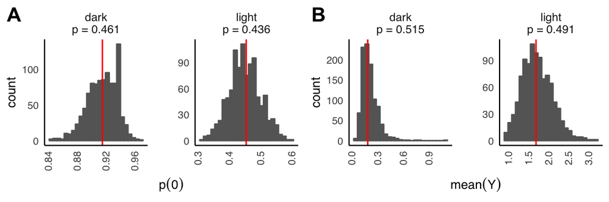

```r
d15l.e.pp <- pp.plots(thesim = d15l.e.sim, thedat = d15l, thefact = 'light', theresponse = 'eggs')
print(d15l.e.pp$plots)
```

Repeat summary statistic calculations for $n=4$ categories:

```r
d15l[,'condition'] <- paste0(d15l[,'light'],'_',d15l[,'temp'])
d15l.e.pp2 <- pp.plots(thesim = d15l.e.sim, thedat = d15l, thefact = 'condition', theresponse = 'eggs', fourcat = TRUE)
```

Output summary statistics:

```r
print(d15l.e.pp2$means)
```

```
## # A tibble: 4 x 4
##         fact      mu2     lower    upper
##        <chr>    <dbl>     <dbl>    <dbl>
## 1  dark_cool 0.048200 0.0000000 0.120000
## 2  dark_warm 0.365820 0.1300000 0.810000
## 3 light_cool 1.830778 0.9492424 3.020455
## 4 light_warm 1.601273 0.8383838 2.767929
```

#### Output model coefficients:

```r
OUTDIR <- "./model_output/"
# d14f stipples
write.table(d14f.ci, file = paste0(OUTDIR,"d14f.stips_ci.txt"), sep = '\t')
write.table(d14f.coef, file = paste0(OUTDIR,"d14f.stips_coef.txt"), sep = '\t')

# d14l stipples
write.table(d14l.ci, file = paste0(OUTDIR,"d14l.stips_ci.txt"), sep = '\t')
write.table(d14l.coef, file = paste0(OUTDIR,"d14l.stips_coef.txt"), sep = '\t')

# d15l stipples
write.table(d15l.s.ci, file = paste0(OUTDIR,"d15l.stips_ci.txt"), sep = '\t')
write.table(d15l.s.coef, file = paste0(OUTDIR,"d15l.stips_coef.txt"), sep = '\t')

# d15l eggs
write.table(d15l.e.ci, file = paste0(OUTDIR,"d15l.eggs_ci.txt"), sep = '\t')
write.table(d15l.e.coef, file = paste0(OUTDIR,"d15l.eggs_coef.txt"), sep = '\t')
```